# GLS Activity: Coverage

# Set the scene

Describe the working environment.

```r
# Attach these packages so their functions don't need to be qualified
library(magrittr) # pipes
library(dplyr)    # disable when temp lines are removed
library(ggplot2)  # graphs
library(ggpubr)   # documents
```

```r
# Call `base::source()` on any repo file that defines functions needed below.
base::source("./scripts/common-functions.R")
```

```r
path_file_input <- "./data-unshared/derived/0-greeted-gls.rds"
html_flip <- FALSE
baseSize <- 10
```

```r
#Put code in here.  It doesn't call a chunk in the codebehind file.
```

```r
dto      <- readRDS(path_file_input)
dto %>% pryr::object_size(); dto %>% class(); dto %>% names()
```

```
112 kB
```

```
[1] "tbl_df"     "tbl"        "data.frame"
```

```
[1] "region"         "audience"       "county_zipcode" "type_training"  "n_trained"      "date"
[7] "county"         "zipcode"
```

```r
# assign aliases for this report
ds <- dto
```

```r
# create auxilary variables
ds <- ds %>%
  dplyr::select(-county_zipcode) %>%
  dplyr::mutate(
    year = lubridate::year(date)
    ,month = lubridate::month(date)
    ,weekday = lubridate::wday(date)
    ,rgn = car::recode(
      region,
      "
      'central'='CN'
     ;'southeast'='SE'
     ;'northeast'='NE  '
      "
    )
  )

ds %>% glimpse(60)
```

```
Observations: 1,017
Variables: 11
$ region        <chr> "central", "central", "central", ...
$ audience      <chr> "professionals", "professionals",...
$ type_training <chr> "QPR", "QPR", "QPR", "QPR", "QPR"...
$ n_trained     <dbl> 7, 35, 21, 21, 25, 22, 19, 24, 14...
$ date          <date> 2015-07-16, 2015-08-07, 2015-09-...
$ county        <chr> "Orange", "Brevard", "Orange", "O...
$ zipcode       <chr> "32825", "32796", "32804", "32804...
$ year          <dbl> 2015, 2015, 2015, 2015, 2015, 201...
$ month         <dbl> 7, 8, 9, 10, 10, 11, 12, 1, 2, 2,...
$ weekday       <dbl> 5, 6, 6, 7, 1, 5, 4, 6, 5, 1, 7, ...
$ rgn           <chr> "CN", "CN", "CN", "CN", "CN", "CN...
```

```r
# ds %>% explore::explore( )
ds %>% explore::describe()
```

| variable | type | na | na_pct | unique | min | mean | max |
| --- | --- | --- | --- | --- | --- | --- | --- |
| region | chr | 0 | 0.0 | 3 | NA | NA | NA |
| audience | chr | 0 | 0.0 | 2 | NA | NA | NA |
| type_training | chr | 0 | 0.0 | 271 | NA | NA | NA |
| n_trained | dou | 12 | 1.2 | 83 | 0 | 35.21 | 3200 |
| date | dat | 4 | 0.4 | 656 | NA | NA | NA |
| county | chr | 31 | 3.0 | 28 | NA | NA | NA |
| zipcode | chr | 96 | 9.4 | 140 | NA | NA | NA |
| year | dou | 4 | 0.4 | 7 | 2014 | 2017.03 | 2019 |
| month | dou | 4 | 0.4 | 13 | 1 | 6.22 | 12 |
| weekday | dou | 4 | 0.4 | 8 | 1 | 4.74 | 7 |
| rgn | chr | 0 | 0.0 | 3 | NA | NA | NA |

# I Exposition

## all regions

Trained PROFESSIONALS by training type (for all years)

| county | total_trained | Care Coordination | Family Training | Postvention | QPR | QPRT |
| --- | --- | --- | --- | --- | --- | --- |
| Orange (central) | 2333 | 140 | 96 | 106 | 1957 | 34 |
| St Lucie (southeast) | 1213 | 44 | 40 | . | 1073 | 56 |
| Volusia (northeast) | 816 | 65 | 42 | 14 | 652 | 43 |
| Lake (northeast) | 660 | 36 | 64 | . | 524 | 36 |
| Palm Beach (southeast) | 610 | 110 | 42 | . | 448 | 10 |
| Seminole (central) | 517 | 18 | 141 | 54 | 267 | 37 |
| Brevard (central) | 502 | 254 | 11 | 87 | 146 | 4 |
| St Johns (northeast) | 248 | 27 | 10 | 55 | 152 | 4 |
| Duval (northeast) | 235 | 5 | . | . | 220 | 10 |
| Hernando (northeast) | 215 | . | 85 | . | 130 | . |
| Indian River (southeast) | 195 | . | . | . | 194 | 1 |
| Marion (northeast) | 195 | . | 53 | 48 | 94 | . |
| Osceola (central) | 135 | 24 | 9 | . | 83 | 19 |
| Clay (northeast) | 127 | . | 28 | . | 99 | . |
| Martin (southeast) | 123 | 26 | . | . | 97 | . |
| Sumter (northeast) | 105 | . | . | . | 92 | 13 |
| Flagler (northeast) | 104 | 12 | . | . | 92 | . |
| Citrus (northeast) | 77 | . | 27 | . | 50 | . |
| Levy (northeast) | 34 | . | . | . | 34 | . |
| Okeechobee (southeast) | 22 | . | . | . | 22 | . |
| NA (northeast) | 19 | . | 19 | . | . | . |
| Putnam (northeast) | 13 | . | 7 | . | 6 | . |
| Polk (central) | 11 | . | . | . | 11 | . |
| Leon (northeast) | 8 | . | 8 | . | . | . |
| Pasco (northeast) | 6 | . | . | . | 6 | . |

Trained PROFESSIONALS by year (for all training types)

| county | total_trained | 2014 | 2015 | 2016 | 2017 | 2018 | 2019 | <NA> |
| --- | --- | --- | --- | --- | --- | --- | --- | --- |
| Orange (central) | 2333 | . | 81 | 363 | 1161 | 582 | 146 | . |
| St Lucie (southeast) | 1213 | . | 49 | 230 | 551 | 356 | 27 | . |
| Volusia (northeast) | 816 | . | 20 | 174 | 238 | 342 | 28 | 14 |
| Lake (northeast) | 660 | . | 19 | 136 | 135 | 312 | 58 | . |
| Palm Beach (southeast) | 610 | . | 4 | 46 | 191 | 290 | 79 | . |
| Seminole (central) | 517 | . | 19 | 192 | 208 | 84 | 14 | . |
| Brevard (central) | 502 | . | 57 | 89 | 20 | 336 | . | . |
| St Johns (northeast) | 248 | 35 | 50 | 31 | 94 | 29 | 9 | . |
| Duval (northeast) | 235 | . | 148 | 65 | 22 | . | . | . |
| Hernando (northeast) | 215 | . | 21 | 85 | 25 | 20 | 64 | . |
| Indian River (southeast) | 195 | . | . | 67 | 51 | 27 | 50 | . |
| Marion (northeast) | 195 | . | 36 | 32 | 51 | 28 | . | 48 |
| Osceola (central) | 135 | . | . | 25 | 59 | 36 | 15 | . |
| Clay (northeast) | 127 | 28 | 25 | . | . | 74 | . | . |
| Martin (southeast) | 123 | . | . | . | 46 | 51 | . | 26 |
| Sumter (northeast) | 105 | . | 18 | 29 | 34 | . | 24 | . |
| Flagler (northeast) | 104 | . | . | 10 | 19 | 49 | 26 | . |
| Citrus (northeast) | 77 | . | 28 | 10 | . | 39 | . | . |
| Levy (northeast) | 34 | . | . | . | . | 34 | . | . |
| Okeechobee (southeast) | 22 | . | . | 13 | 8 | 1 | . | . |
| NA (northeast) | 19 | . | . | . | . | 19 | . | . |
| Putnam (northeast) | 13 | . | . | 7 | 6 | . | . | . |
| Polk (central) | 11 | . | . | 11 | . | . | . | . |
| Leon (northeast) | 8 | . | . | . | . | . | 8 | . |
| Pasco (northeast) | 6 | . | . | 6 | . | . | . | . |

Trained IN COMMUNITY by year (for all training types)

| county | total_trained | 2015 | 2016 | 2017 | 2018 | 2019 | <NA> |
| --- | --- | --- | --- | --- | --- | --- | --- |
| Orange (central) | 9277 | 1535 | 2823 | 3764 | 955 | 200 | . |
| Volusia (northeast) | 3948 | 125 | 1208 | 837 | 1438 | 340 | . |
| Seminole (central) | 2560 | 200 | 1550 | 650 | 160 | . | . |
| St Lucie (southeast) | 2113 | 25 | 88 | 955 | 830 | 215 | . |
| Palm Beach (southeast) | 1925 | 25 | 305 | 455 | 920 | 220 | . |
| Brevard (central) | 1481 | 186 | 500 | 440 | 310 | 45 | . |
| Flagler (northeast) | 1375 | . | 160 | 237 | 743 | 235 | . |
| Martin (southeast) | 1000 | . | 45 | 490 | 340 | 125 | . |
| West Palm Beach (southeast) | 625 | 0 | 50 | 100 | 445 | 30 | . |
| NA (southeast) | 455 | 30 | 425 | . | . | . | . |
| St Johns (northeast) | 389 | 250 | . | . | 109 | . | 30 |
| Marion (northeast) | 325 | 115 | . | 210 | . | . | . |
| NA (northeast) | 309 | 40 | 108 | 160 | . | 1 | . |
| Indian River (southeast) | 245 | 135 | 70 | 40 | . | . | . |
| Lake (northeast) | 206 | 8 | 183 | 15 | . | . | . |
| NA (central) | 200 | 200 | . | . | . | . | . |
| Hernando (northeast) | 115 | . | 115 | . | . | . | . |
| Leon (northeast) | 100 | . | 60 | 40 | . | . | . |
| Sumter (northeast) | 85 | . | 65 | 20 | . | . | . |
| Orlando (central) | 60 | . | 60 | . | . | . | . |
| Fort Lauderdale (southeast) | 35 | . | . | . | 35 | . | . |
| Osceola (central) | 35 | . | . | 35 | . | . | . |

```r
for(region_i in regions_available){
  cat("\n## ", region_i, "\n")
  ds %>% region_table(pick_region = region_i)
  cat("\n")
}
```

## central

Trained PROFESSIONALS by training type (for all years)

| county | total_trained | Care Coordination | Family Training | Postvention | QPR | QPRT |
| --- | --- | --- | --- | --- | --- | --- |
| Orange | 2333 | 140 | 96 | 106 | 1957 | 34 |
| Seminole | 517 | 18 | 141 | 54 | 267 | 37 |
| Brevard | 502 | 254 | 11 | 87 | 146 | 4 |
| Osceola | 135 | 24 | 9 | . | 83 | 19 |
| Polk | 11 | . | . | . | 11 | . |

Trained PROFESSIONALS by year (for all training types)

| county | total_trained | 2015 | 2016 | 2017 | 2018 | 2019 |
| --- | --- | --- | --- | --- | --- | --- |
| Orange | 2333 | 81 | 363 | 1161 | 582 | 146 |
| Seminole | 517 | 19 | 192 | 208 | 84 | 14 |
| Brevard | 502 | 57 | 89 | 20 | 336 | . |
| Osceola | 135 | . | 25 | 59 | 36 | 15 |
| Polk | 11 | . | 11 | . | . | . |

Trained IN COMMUNITY by year (for all training types)

| county | total_trained | 2015 | 2016 | 2017 | 2018 | 2019 |
| --- | --- | --- | --- | --- | --- | --- |
| Orange | 9277 | 1535 | 2823 | 3764 | 955 | 200 |
| Seminole | 2560 | 200 | 1550 | 650 | 160 | . |
| Brevard | 1481 | 186 | 500 | 440 | 310 | 45 |
| . | 200 | 200 | . | . | . | . |
| Orlando | 60 | . | 60 | . | . | . |
| Osceola | 35 | . | . | 35 | . | . |

## southeast

Trained PROFESSIONALS by training type (for all years)

| county | total_trained | Care Coordination | Family Training | QPR | QPRT |
| --- | --- | --- | --- | --- | --- |
| St Lucie | 1213 | 44 | 40 | 1073 | 56 |
| Palm Beach | 610 | 110 | 42 | 448 | 10 |
| Indian River | 195 | . | . | 194 | 1 |
| Martin | 123 | 26 | . | 97 | . |
| Okeechobee | 22 | . | . | 22 | . |

Trained PROFESSIONALS by year (for all training types)

| county | total_trained | 2015 | 2016 | 2017 | 2018 | 2019 | <NA> |
| --- | --- | --- | --- | --- | --- | --- | --- |
| St Lucie | 1213 | 49 | 230 | 551 | 356 | 27 | . |
| Palm Beach | 610 | 4 | 46 | 191 | 290 | 79 | . |
| Indian River | 195 | . | 67 | 51 | 27 | 50 | . |
| Martin | 123 | . | . | 46 | 51 | . | 26 |
| Okeechobee | 22 | . | 13 | 8 | 1 | . | . |

Trained IN COMMUNITY by year (for all training types)

| county | total_trained | 2015 | 2016 | 2017 | 2018 | 2019 |
| --- | --- | --- | --- | --- | --- | --- |
| St Lucie | 2113 | 25 | 88 | 955 | 830 | 215 |
| Palm Beach | 1925 | 25 | 305 | 455 | 920 | 220 |
| Martin | 1000 | . | 45 | 490 | 340 | 125 |
| West Palm Beach | 625 | 0 | 50 | 100 | 445 | 30 |
| . | 455 | 30 | 425 | . | . | . |
| Indian River | 245 | 135 | 70 | 40 | . | . |
| Fort Lauderdale | 35 | . | . | . | 35 | . |

## northeast

Trained PROFESSIONALS by training type (for all years)

| county | total_trained | Care Coordination | Family Training | Postvention | QPR | QPRT |
| --- | --- | --- | --- | --- | --- | --- |
| Volusia | 816 | 65 | 42 | 14 | 652 | 43 |
| Lake | 660 | 36 | 64 | . | 524 | 36 |
| St Johns | 248 | 27 | 10 | 55 | 152 | 4 |
| Duval | 235 | 5 | . | . | 220 | 10 |
| Hernando | 215 | . | 85 | . | 130 | . |
| Marion | 195 | . | 53 | 48 | 94 | . |
| Clay | 127 | . | 28 | . | 99 | . |
| Sumter | 105 | . | . | . | 92 | 13 |
| Flagler | 104 | 12 | . | . | 92 | . |
| Citrus | 77 | . | 27 | . | 50 | . |
| Levy | 34 | . | . | . | 34 | . |
| . | 19 | . | 19 | . | . | . |
| Putnam | 13 | . | 7 | . | 6 | . |
| Leon | 8 | . | 8 | . | . | . |
| Pasco | 6 | . | . | . | 6 | . |

Trained PROFESSIONALS by year (for all training types)

| county | total_trained | 2014 | 2015 | 2016 | 2017 | 2018 | 2019 | <NA> |
| --- | --- | --- | --- | --- | --- | --- | --- | --- |
| Volusia | 816 | . | 20 | 174 | 238 | 342 | 28 | 14 |
| Lake | 660 | . | 19 | 136 | 135 | 312 | 58 | . |
| St Johns | 248 | 35 | 50 | 31 | 94 | 29 | 9 | . |
| Duval | 235 | . | 148 | 65 | 22 | . | . | . |
| Hernando | 215 | . | 21 | 85 | 25 | 20 | 64 | . |
| Marion | 195 | . | 36 | 32 | 51 | 28 | . | 48 |
| Clay | 127 | 28 | 25 | . | . | 74 | . | . |
| Sumter | 105 | . | 18 | 29 | 34 | . | 24 | . |
| Flagler | 104 | . | . | 10 | 19 | 49 | 26 | . |
| Citrus | 77 | . | 28 | 10 | . | 39 | . | . |
| Levy | 34 | . | . | . | . | 34 | . | . |
| . | 19 | . | . | . | . | 19 | . | . |
| Putnam | 13 | . | . | 7 | 6 | . | . | . |
| Leon | 8 | . | . | . | . | . | 8 | . |
| Pasco | 6 | . | . | 6 | . | . | . | . |

Trained IN COMMUNITY by year (for all training types)

| county | total_trained | 2015 | 2016 | 2017 | 2018 | 2019 | <NA> |
| --- | --- | --- | --- | --- | --- | --- | --- |
| Volusia | 3948 | 125 | 1208 | 837 | 1438 | 340 | . |
| Flagler | 1375 | . | 160 | 237 | 743 | 235 | . |
| St Johns | 389 | 250 | . | . | 109 | . | 30 |
| Marion | 325 | 115 | . | 210 | . | . | . |
| . | 309 | 40 | 108 | 160 | . | 1 | . |
| Lake | 206 | 8 | 183 | 15 | . | . | . |
| Hernando | 115 | . | 115 | . | . | . | . |
| Leon | 100 | . | 60 | 40 | . | . | . |
| Sumter | 85 | . | 65 | 20 | . | . | . |

# II. Development

## 1 County scatter

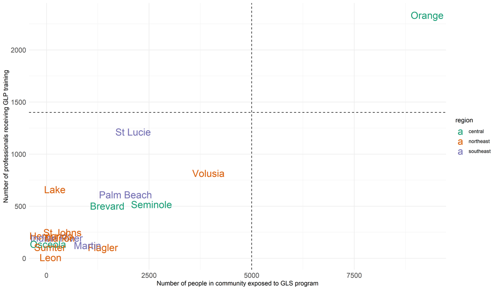

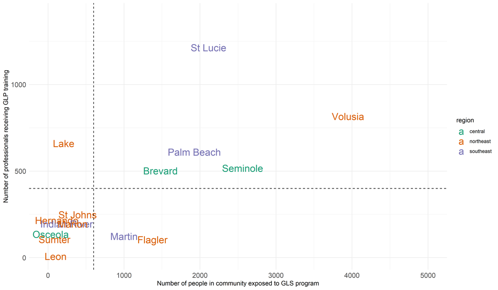

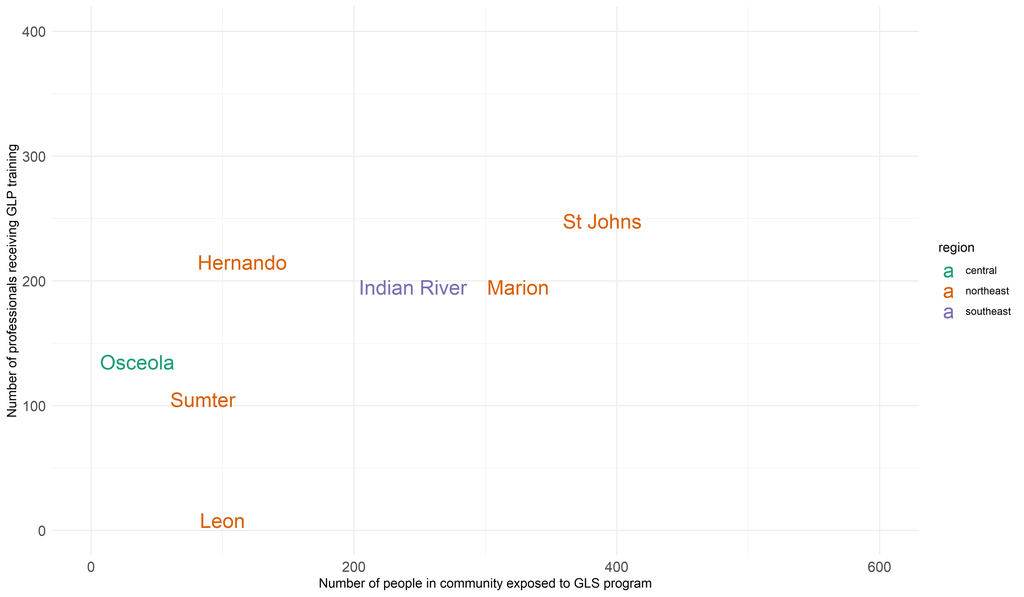

## 2 Coverage - DUAL

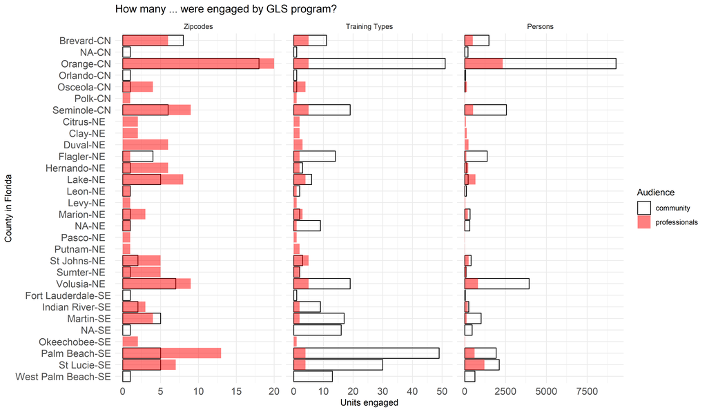

```r
ds %>% show_coverage()
```

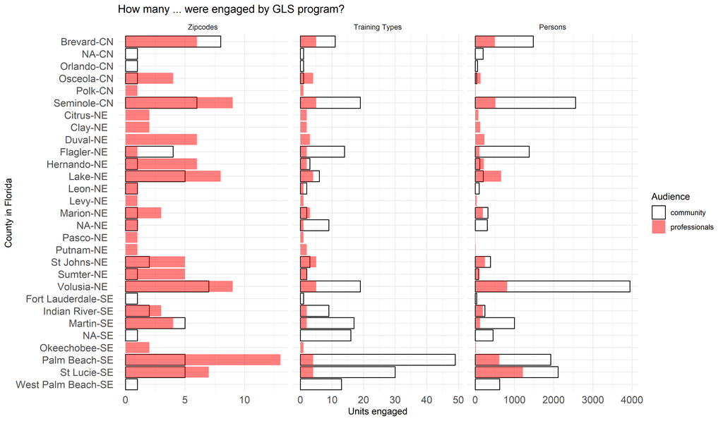

```r
# to remove the outlier
ds %>%
  dplyr::filter( !county %in% c("Orange") ) %>%
  show_coverage()
```

## 3 Coverage - Professionals

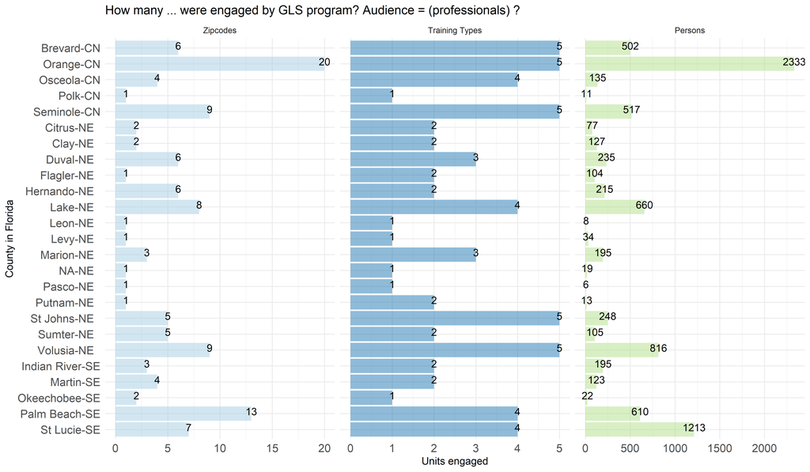

```r
ds %>% show_coverage("professionals")
```

## 4 Coverage - Community

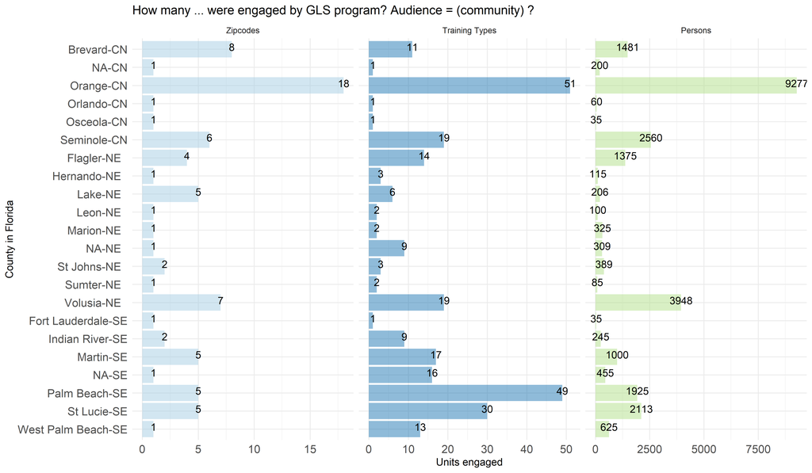

```r
ds %>% show_coverage("community")
```

# III. Recapitulation

- **Orange** county received the most of GLS programming (1-scatter](#1_county_scatter))
  - The next cluser of counties with high programming:
    - **Volusia** + **St Lucie**
    - **Palrm Beach** + **Brevard** + **Seminole**
    - **Lake**

# Session Information

For the sake of documentation and reproducibility, the current report was rendered in the following environment. Click the line below to expand.

Report rendered by an499583 at 2019-06-07, 10:40 -0700 in 19 seconds.